# prediction_analysis

2023-05-18

```r
library(mgcv)
require(parallel)
```

Load and subset complete SA preprocessed data file.

```r
alldata <- read.csv("data/intra_day/SA_preprocessed.csv")[,c("dt", "Temp", "Demand", "Time", "DSTTime", "Year", "WtdTemp")]
alldata$dt <- fasttime::fastPOSIXct(alldata$dt, tz="UTC")
head(alldata)
```

```
##                    dt  Temp Demand      Time   DSTTime         Year  WtdTemp
## 1 2018-03-06 09:30:00 20.75   1288 0.3750000 0.4166667 0.000000e+00 20.48750
## 2 2018-03-06 10:00:00 21.50   1237 0.3958333 0.4375000 5.707763e-05 20.92197
## 3 2018-03-06 10:30:00 22.25   1189 0.4166667 0.4583333 1.141553e-04 21.35000
## 4 2018-03-06 11:00:00 23.00   1150 0.4375000 0.4791667 1.712329e-04 21.80000
## 5 2018-03-06 11:30:00 23.55   1122 0.4583333 0.5000000 2.283105e-04 22.13000
## 6 2018-03-06 12:00:00 24.10   1102 0.4791667 0.5208333 2.853881e-04 22.46000
```

Define model formula.

```r
gamlwmod <- Demand ~  s(DSTTime, bs = "cc", k = 12) + s(WtdTemp, bs = "tp", k =8) + s(Year, bs = "tp", k =7)
```

Build offset matrix by # of observations and # of seconds.

```r
day.offset = c(day=1, week=7, month=30, year=365)
ahead = cbind(seconds=day.offset*60*60*24, obs=day.offset*24*2)
ahead
```

```
##        seconds   obs
## day      86400    48
## week    604800   336
## month  2592000  1440
## year  31536000 17520
```

# 365 Day Sliding Window

Build model endpoint vector - the row number of the final training observation for each model.

```r
endpts <- seq(ahead["year", "obs"] + 1,
              nrow(alldata)-ahead["year", "obs"],
              by=ahead["week", "obs"])
length(endpts)
```

```
## [1] 157
```

The above number of models can be fit on a complete year of data, with data available to predict a year ahead.

Estimating time to fit a year of data and make the X-ahead predictions.

```r
system.time({
  endpt <- ahead["year", "obs"]
  train <- alldata[1:endpt,]
  test <- alldata[(endpt + ahead[,"obs"]),]
  model <- gamm(gamlwmod, data=train)$gam
  pred <- predict(model, test)
  print(length(pred))
})
```

```
## [1] 4
```

```
##    user  system elapsed
##   3.058   0.123   3.188
```

With ~3 seconds per model required, dealing with them all serially would take a total of around 10 minutes.

```r
fit_pred <- function(endpt) {
  train <- alldata[(endpt-90):endpt,]
  test <- alldata[(endpt + ahead[,"obs"]),]
  model <- gamm(gamlwmod, data=train)$gam
  predict(model, test)
}
system.time({
  for (endpt in endpts) {
    fit_pred(endpt)
  }
})
```

```
##    user  system elapsed
##  12.890   0.050  12.981
```

```r
system.time(parallel::mclapply(endpts, fit_pred))
```

```
##    user  system elapsed
##   6.311   0.174   6.821
```

The default number of cores is apparently 2, so speedup scales linearly with cores. My machine has 8 cores so let’s put them to use!

```r
fit_pred <- function(endpt) {
  train <- alldata[(endpt - ahead["year", "obs"]):endpt,]
  test <- alldata[(endpt + ahead[,"obs"]),]
  model <- gamm(gamlwmod, data=train)$gam
  predict(model, test)
}
lout <- parallel::mclapply(endpts, fit_pred, mc.cores=8)
mout <- matrix(unlist(lout), ncol=4)
dim(mout)
```

```
## [1] 157   4
```

Predictions at varying delay after model endpoint are now available for each of the models.

Now to get the true values in the same format.

```r
true.lout <- lapply(seq_along(endpts), function(i) alldata[names(lout[[i]]), "Demand"])

true.mout <- matrix(unlist(true.lout), ncol=4)
dim(true.mout)
```

```
## [1] 157   4
```

Plot squared errors of X-ahead predictions across all models.

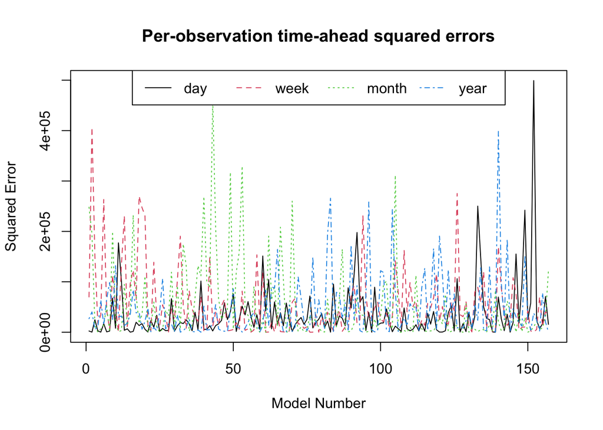

```r
sqerr.mat <- (true.mout - mout)^2

matplot(sqerr.mat, type='l', main="Per-observation time-ahead squared errors", xlab="Model Number", ylab="Squared Error")
legend("top", legend=rownames(ahead), col=1:4, lty=1:4, ncol=4)
```

That’s not very informative. Maybe a density plot will be.

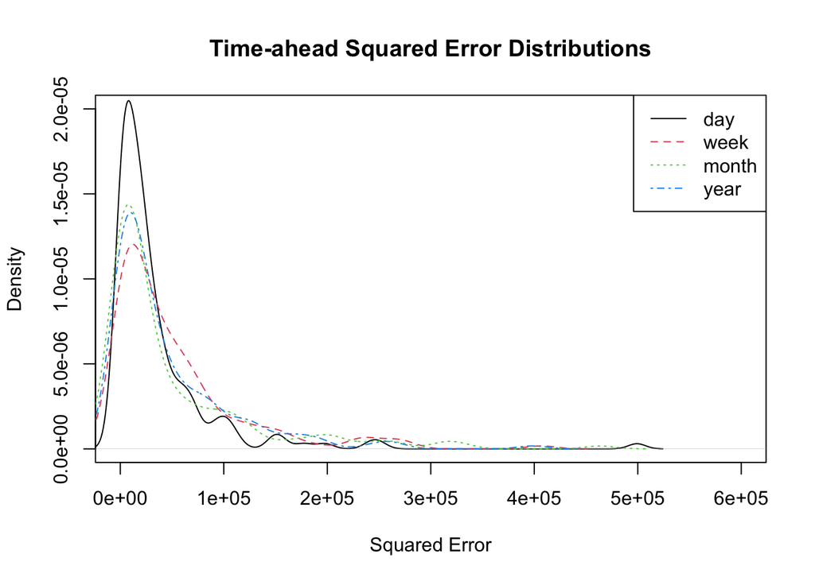

```r
plot(density(sqerr.mat[,1]), col=1, lty=1, ylim=c(0, 2e-5), xlim=c(0, 6e5),
     main="Time-ahead Squared Error Distributions", xlab="Squared Error")
for (i in 2:4) {
  lines(density(sqerr.mat[,i]), col=i, lty=i)
}
legend("topright", legend=rownames(ahead), col=1:4, lty=1:4)
```

I suppose the “better” distributions should have a big peak and short tail. Suprisingly, week-ahead seems to be the worst.

```r
mse <- t(t(colMeans(sqerr.mat)))
rownames(mse) <- rownames(ahead)
mse
```

```
##           [,1]
## day   35792.33
## week  52994.38
## month 50755.09
## year  46435.03
```

Mean Squared Errors agree that week-ahead prediction is the worst.

Maybe plotting the residual distributions will be most informative.

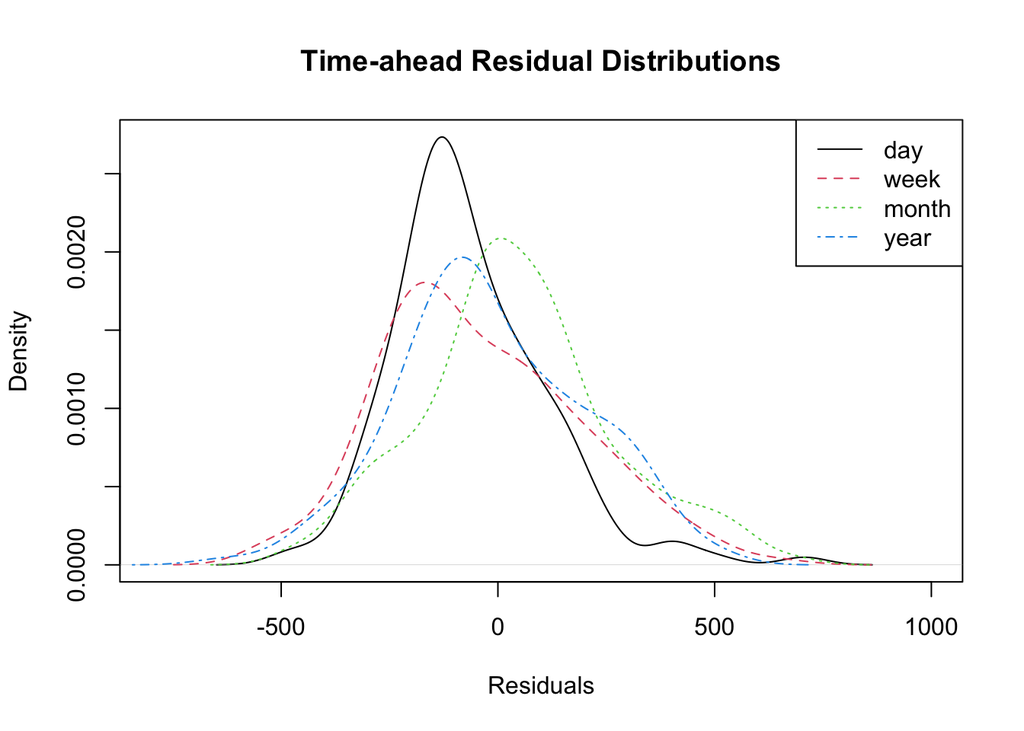

```r
residual.mat <- mout - true.mout
plot(density(residual.mat[,1]), col=1, lty=1, xlim=c(-800, 1000),
     main="Time-ahead Residual Distributions", xlab="Residuals")
for (i in 2:4) {
  lines(density(residual.mat[,i]), col=i, lty=i)
}
legend("topright", legend=rownames(ahead), col=1:4, lty=1:4)
```

All but month-ahead predictions most often underestimate demand.

# 372 Day Sliding Window

Day-ahead prediction should theoretically be the best. Maybe a 372-day sliding window, which includes the previous year’s previous week, will improve day-ahead.

Rebuild model endpoint vector.

```r
days372 <- ahead["year", "obs"] + ahead["week", "obs"]
endpts2 <- seq(days372 + 1,
              nrow(alldata) - ahead["year", "obs"],
              by=ahead["week", "obs"])
length(endpts2)
```

```
## [1] 156
```

Refit model prediction and squared error matrices.

```r
fit_pred2 <- function(endpt) {
  train <- alldata[(endpt - days372):endpt,]
  test <- alldata[(endpt + ahead[,"obs"]),]
  model <- gamm(gamlwmod, data=train)$gam
  predict(model, test)
}
lout2 <- parallel::mclapply(endpts2, fit_pred2, mc.cores=8)
mout2 <- matrix(unlist(lout2), ncol=4)

true.lout2 <- lapply(seq_along(endpts2),
                    function(i) alldata[names(lout2[[i]]), "Demand"])
true.mout2 <- matrix(unlist(true.lout2), ncol=4)
sqerr.mat2 <- (true.mout2 - mout2)^2
```

Plot squared error distributions.

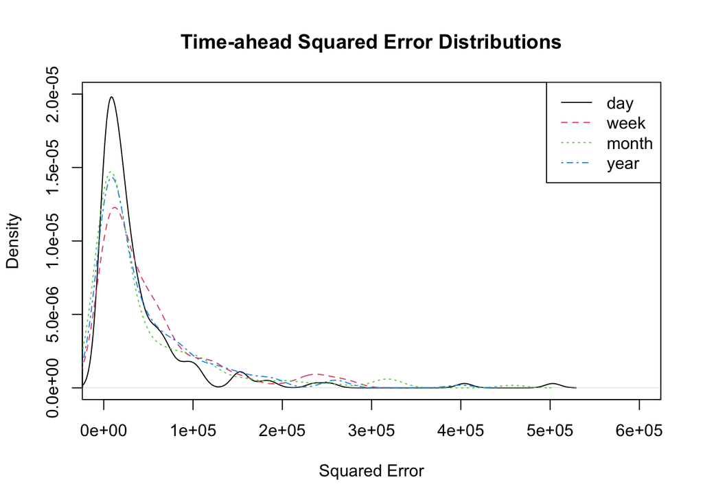

```r
plot(density(sqerr.mat2[,1]), col=1, lty=1, ylim=c(0, 2e-5), xlim=c(0, 6e5),
     main="Time-ahead Squared Error Distributions", xlab="Squared Error")
for (i in 2:4) {
  lines(density(sqerr.mat2[,i]), col=i, lty=i)
}
legend("topright", legend=rownames(ahead), col=1:4, lty=1:4)
```

Show MSE.

```r
mse2 <- t(t(colMeans(sqerr.mat2)))
rownames(mse2) <- rownames(ahead)
mses <- cbind(mse, mse2)
colnames(mses) <- c("365 days", "372 days")
mses
```

```
##       365 days 372 days
## day   35792.33 39300.54
## week  52994.38 52705.62
## month 50755.09 48657.55
## year  46435.03 46391.43
```

Plot residual distributions.

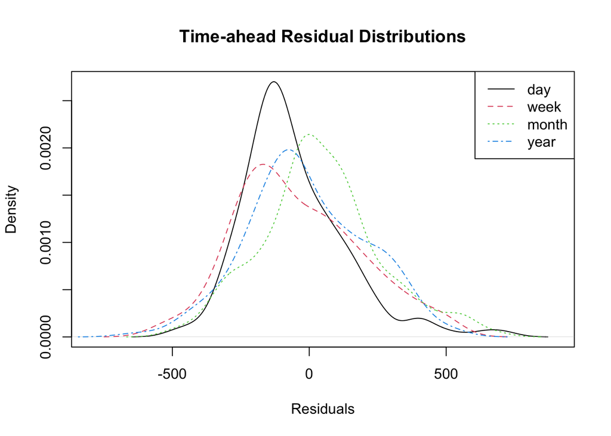

```r
residual.mat2 <- mout2 - true.mout2
plot(density(residual.mat2[,1]), col=1, lty=1, xlim=c(-800, 900),
     main="Time-ahead Residual Distributions", xlab="Residuals")
for (i in 2:4) {
  lines(density(residual.mat2[,i]), col=i, lty=i)
}
legend("topright", legend=rownames(ahead), col=1:4, lty=1:4)
```